# Assignment 2: Spatial Analysis and Visualization

Healthcare Access and Equity in Pennsylvania

Author

Chloe Robinson

Published

December 1, 2025

## Assignment Overview

**Learning Objectives:** - Apply spatial operations to answer policy-relevant research questions - Integrate census demographic data with spatial analysis - Create publication-quality visualizations and maps - Work with spatial data from multiple sources - Communicate findings effectively for policy audiences

## Part 1: Healthcare Access for Vulnerable Populations

### Research Question

**Which Pennsylvania counties have the highest proportion of vulnerable populations (elderly + low-income) living far from hospitals?**

Your analysis should identify counties that should be priorities for healthcare investment and policy intervention.

### Required Analysis Steps

Complete the following analysis, documenting each step with code and brief explanations:

#### Step 1: Data Collection (5 points)

Load the required spatial data: - Pennsylvania county boundaries - Pennsylvania hospitals (from lecture data) - Pennsylvania census tracts

**Your Task:**

```r
# Load required packages
library(sf)
library(tidyverse)
library(tigris)
library(tidycensus)
library(scales)
library(patchwork)
library(here)
library(knitr)

census_api_key("42bf8a20a3df1def380f330cf7edad0dd5842ce6")

#load data
options(tigris_use_cache = TRUE, tigris_progress = FALSE)

pa_counties <- sf::st_read("Data/Pennsylvania_County_Boundaries.shp", quiet = TRUE)
hospitals   <- sf::st_read("Data/hospitals.geojson", quiet = TRUE)

suppressMessages(suppressWarnings({
  invisible(capture.output(
    { census_tracts <- tigris::tracts(state = "PA", cb = TRUE, year = 2022) },
    type = "message"
  ))
}))

census_tracts <- tracts(state = "PA", cb = TRUE, year = 2022)

# Check that all data loaded correctly

hospitals <- st_transform(hospitals, st_crs(pa_counties))
census_tracts <- st_transform(census_tracts, st_crs(pa_counties))

invisible(st_crs(hospitals))
invisible(st_crs(census_tracts))
invisible(st_crs(pa_counties))
```

**Questions to answer:** - How many hospitals are in your dataset? 223 - How many census tracts? 3445 - What coordinate reference system is each dataset in? WGS 84

#### Step 2: Get Demographic Data

Use `tidycensus` to download tract-level demographic data for Pennsylvania.

**Required variables:** - Total population - Median household income - Population 65 years and over (you may need to sum multiple age categories)

**Your Task:**

```r
# Get demographic data from ACS
demographics <- get_acs(
  geography = "tract",
  variables = c(
    total_pop = "B01003_001",
    median_income = "B19013_001"
  ),
  state = "PA",
  year = 2022,
  survey = "acs5",
  output = "wide"
)

over_65_vars <- c(
  "B01001_020", "B01001_021", "B01001_022", "B01001_023", "B01001_024", "B01001_025",
  "B01001_044", "B01001_045", "B01001_046", "B01001_047", "B01001_048", "B01001_049"
)

over_65 <- get_acs(
  geography = "tract",
  state = "PA",
  year = 2022,
  survey = "acs5",
  variables = over_65_vars,
  output = "wide"
)


# sum across all the *_E columns (estimates)
over_65 <- transform(
  over_65,
  over65_total = B01001_020E + B01001_021E + B01001_022E +
                 B01001_023E + B01001_024E + B01001_025E +
                 B01001_044E + B01001_045E + B01001_046E +
                 B01001_047E + B01001_048E + B01001_049E
)

# Join to tract boundaries
demographics_boundaries <- census_tracts %>%
  left_join(demographics, by = "GEOID") %>%
  left_join(over_65 %>% select(GEOID, over65_total), by = "GEOID")

#How many tracts have missing income data?
sum(is.na(demographics$median_incomeE))
```

```
[1] 63
```

```r
#Median income across all PA census tracts?
median(demographics$median_incomeE, na.rm = TRUE)
```

```
[1] 70188
```

**Questions to answer:** - What year of ACS data are you using? 2022 - How many tracts have missing income data? 63 - What is the median income across all PA census tracts? $70,188

#### Step 3: Define Vulnerable Populations

Identify census tracts with vulnerable populations based on TWO criteria: 1. Low median household income (choose an appropriate threshold) 2. Significant elderly population (choose an appropriate threshold)

**Your Task:**

```r
# Filter for vulnerable tracts based on your criteria
low_income_threshold <- 50000

demographics_boundaries <- demographics_boundaries %>%
  mutate(low_income = median_incomeE < low_income_threshold)

#Number of tracts below the median income of 50000
sum(demographics_boundaries$low_income, na.rm = TRUE)
```

```
[1] 619
```

```r
#Percent of each tract with population over 65
high_elderly_threshold <- 0.20

demographics_boundaries <- demographics_boundaries %>%
  mutate(pct_over_65 = over65_total /total_popE)

demographics_boundaries <- demographics_boundaries %>%
  mutate(
    low_income = median_incomeE < low_income_threshold,
    high_elderly = pct_over_65 >= high_elderly_threshold,
    vulnerable = low_income & high_elderly
  )

table(demographics_boundaries$vulnerable)
```

```
FALSE  TRUE
 3238   171
```

```r
vulnerable_tracts <- demographics_boundaries %>%
  filter(vulnerable == TRUE)
```

**Questions to answer:** - What income threshold did you choose and why? The median income is $70,188, so I chose $50,000 as the low income threshold as it’s below the median income. - What elderly population threshold did you choose and why? I chose 20% because the US Census Bureau states that in 2022, 17.3% of the U.S. were over the age of 65. - How many tracts meet your vulnerability criteria? 171 - What percentage of PA census tracts are considered vulnerable by your definition? 4.96%

#### Step 4: Calculate Distance to Hospitals

For each vulnerable tract, calculate the distance to the nearest hospital.

**Your Task:**

```r
# Transform to appropriate projected CRS - need to do math calculations in projected
vulnerable_tracts_proj <- vulnerable_tracts %>%
  st_transform(3365)

hospitals_proj <- hospitals %>%
  st_transform(3365)

# Find tract centroids
tract_centroids <- st_point_on_surface(vulnerable_tracts_proj)

# Nearest hospital for each tract
nearest_hospitals <- st_nearest_feature(tract_centroids, hospitals_proj)

# Dist
tract_distances <- st_distance(
  tract_centroids,
  hospitals_proj[nearest_hospitals, ],
  by_element = TRUE
)

# Convert feet to miles & go back to original crs now that the math calc is done
vulnerable_tracts <- vulnerable_tracts %>%
  mutate(
    dist_ft = as.numeric(tract_distances),
    dist_mi = dist_ft / 5280
  )

avg_dist_mi <- mean(vulnerable_tracts$dist_mi, na.rm = TRUE)
max_dist_mi <- max(vulnerable_tracts$dist_mi, na.rm = TRUE)
vulnerable_over_15   <- sum(vulnerable_tracts$dist_mi > 15, na.rm = TRUE)

summary(vulnerable_tracts$dist_mi)
```

```
    Min.  1st Qu.   Median     Mean  3rd Qu.     Max.
 0.03159  0.99814  2.01451  3.59131  3.87643 18.90979
```

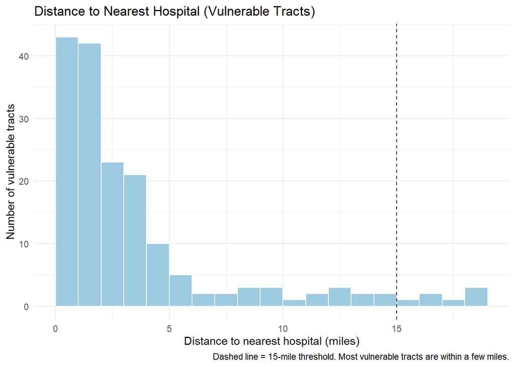

```r
vuln_dist <- vulnerable_tracts %>%
  st_drop_geometry() %>%
  dplyr::filter(!is.na(dist_mi))

ggplot(vuln_dist, aes(x = dist_mi)) +
  geom_histogram(binwidth = 1, color = "white", fill = "#9ecae1", boundary = 0, closed = "left") +
  geom_vline(xintercept = 15, linetype = "dashed") +
  labs(
    title = "Distance to Nearest Hospital (Vulnerable Tracts)",
    x = "Distance to nearest hospital (miles)",
    y = "Number of vulnerable tracts",
    caption = "Dashed line = 15-mile threshold. Most vulnerable tracts are within a few miles."
  ) +
  theme_minimal()
```

**Requirements:** - Use an appropriate projected coordinate system for Pennsylvania - PA South State Plane 3365 - Calculate distances in miles - Explain why you chose your projection - This projection is good for calculating areas and distances in Pennsylvania

#### Step 5: Identify Underserved Areas

Define “underserved” as vulnerable tracts that are more than 15 miles from the nearest hospital.

**Your Task:**

```r
# Create underserved variable
vulnerable_tracts <- vulnerable_tracts %>%
  mutate(underserved = dist_mi > 15)

number_vulnerable      <- nrow(vulnerable_tracts)
number_underserved     <- sum(vulnerable_tracts$underserved, na.rm = TRUE)
pct_underserved   <- 100 * number_underserved / number_vulnerable

# Summary data frame
summary_table <- data.frame(
  Metric = c(
    "Total vulnerable tracts",
    "Underserved tracts (>15 miles)",
    "Percent underserved"
  ),
  Value = c(
    number_vulnerable,
    number_underserved,
    paste0(round(pct_underserved, 2), "%")
  )
)

# Display as a formatted table
kable(summary_table,
      caption = "Summary of Vulnerable and Underserved Census Tracts in Pennsylvania",
      align = c("l", "r"))
```

Summary of Vulnerable and Underserved Census Tracts in Pennsylvania

| Metric | Value |
| --- | --- |
| Total vulnerable tracts | 171 |
| Underserved tracts (>15 miles) | 7 |
| Percent underserved | 4.09% |

**Questions to answer:** - How many tracts are underserved? 7 - What percentage of vulnerable tracts are underserved? 4.09% - Does this surprise you? Why or why not?

#### Step 6: Aggregate to County Level

Use spatial joins and aggregation to calculate county-level statistics about vulnerable populations and hospital access.

**Your Task:**

```r
# Spatial join tracts to counties
vuln_for_join <- vulnerable_tracts %>%
  st_transform(st_crs(pa_counties))

# Spatial join: attach county names to vulnerable tracts
vuln_county <- vuln_for_join %>%
  st_join(pa_counties %>% select(COUNTY_NAM), left = TRUE)

# Aggregate statistics by county
county_stats <- pa_counties %>%
  st_drop_geometry() %>%
  select(COUNTY_NAM) %>%
  left_join(
    vuln_county %>%
      st_drop_geometry() %>%
      group_by(COUNTY_NAM) %>%
      summarise(
        vulnerable_tracts    = n(),
        underserved_tracts   = sum(underserved, na.rm = TRUE),
        avg_dist_mi          = mean(dist_mi, na.rm = TRUE),
        vulnerable_pop       = sum(over65_total, na.rm = TRUE),
        underserved_vuln_pop = sum(ifelse(underserved, over65_total, 0), na.rm = TRUE),
        .groups = "drop"
      ),
    by = "COUNTY_NAM"
  ) %>%
  mutate(
    across(c(vulnerable_tracts, underserved_tracts, avg_dist_mi,
             vulnerable_pop, underserved_vuln_pop),
           ~ tidyr::replace_na(., 0)),
    pct_underserved = dplyr::if_else(
      vulnerable_tracts > 0,
      100 * underserved_tracts / vulnerable_tracts,
      0
    )
  )

top5_pct_underserved <- county_stats %>%
  arrange(desc(pct_underserved), desc(avg_dist_mi)) %>%
  slice_head(n = 5) %>%
  pull(COUNTY_NAM)

top5_vuln_people_far <- county_stats %>%
  arrange(desc(underserved_vuln_pop)) %>%
  slice_head(n = 5) %>%
  pull(COUNTY_NAM)
```

**Questions to answer:** - Which 5 counties have the highest percentage of underserved vulnerable tracts? Clarion, Monroe, Perry, Cameron, Cleanfield - Which counties have the most vulnerable people living far from hospitals? Clearfield, Elk, Clarion, Forest, Venango, Warren - Are there any patterns in where underserved counties are located?

#### Step 7: Create Summary Table

Create a professional table showing the top 10 priority counties for healthcare investment.

**Your Task:**

```r
# Create and format priority counties table
priority_counties <- county_stats %>%
  arrange(desc(underserved_vuln_pop), desc(pct_underserved), desc(avg_dist_mi)) %>%
  mutate(
    County                   = COUNTY_NAM,
    `Vulnerable tracts`      = vulnerable_tracts,
    `Underserved tracts`     = underserved_tracts,
    `% underserved`          = scales::percent(pct_underserved / 100, accuracy = 0.1),
    `Avg distance (mi)`      = round(avg_dist_mi, 1),
    `Vulnerable pop (65+)`   = scales::comma(vulnerable_pop),
    `Underserved vuln pop`   = scales::comma(underserved_vuln_pop)
  ) %>%
  select(
    County,
    `Vulnerable tracts`,
    `Underserved tracts`,
    `% underserved`,
    `Avg distance (mi)`,
    `Vulnerable pop (65+)`,
    `Underserved vuln pop`
  ) %>%
  head(10)

knitr::kable(
  priority_counties,
  caption = "Top 10 Pennsylvania counties to prioritize for healthcare access investment (ranked by number of vulnerable 65+ residents living >15 miles from a hospital, then % underserved).",
  align = c("l","r","r","r","r","r","r")
)
```

Top 10 Pennsylvania counties to prioritize for healthcare access investment (ranked by number of vulnerable 65+ residents living >15 miles from a hospital, then % underserved).

| County | Vulnerable tracts | Underserved tracts | % underserved | Avg distance (mi) | Vulnerable pop (65+) | Underserved vuln pop |
| --- | --- | --- | --- | --- | --- | --- |
| CLEARFIELD | 4 | 2 | 50.0% | 12.8 | 2,926 | 1,482 |
| ELK | 2 | 1 | 50.0% | 11.2 | 1,926 | 987 |
| CLARION | 1 | 1 | 100.0% | 18.9 | 802 | 802 |
| FOREST | 2 | 1 | 50.0% | 16.6 | 1,311 | 802 |
| VENANGO | 4 | 1 | 25.0% | 11.5 | 2,094 | 802 |
| WARREN | 5 | 1 | 20.0% | 8.0 | 4,529 | 802 |
| PERRY | 1 | 1 | 100.0% | 16.2 | 492 | 492 |
| JUNIATA | 2 | 1 | 50.0% | 12.3 | 1,332 | 492 |
| HUNTINGDON | 3 | 1 | 33.3% | 13.4 | 1,916 | 492 |
| MIFFLIN | 4 | 1 | 25.0% | 10.1 | 2,598 | 492 |

**Requirements:** - Use `knitr::kable()` or similar for formatting - Include descriptive column names - Format numbers appropriately (commas for population, percentages, etc.) - Add an informative caption - Sort by priority (you decide the metric)

## Part 2: Comprehensive Visualization

Using the skills from Week 3 (Data Visualization), create publication-quality maps and charts.

### Map 1: County-Level Choropleth

Create a choropleth map showing healthcare access challenges at the county level.

**Your Task:**

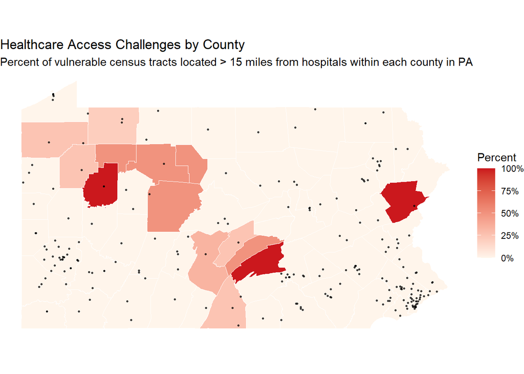

```r
# Change NA to 0
county_stats <- county_stats %>%
  mutate(
    pct_underserved = ifelse(is.na(pct_underserved), 0, pct_underserved)
  )

# County level access map
pa_counties_map <- pa_counties %>%
  left_join(county_stats, by = "COUNTY_NAM")

# Hospitals have same CRS as the map layer
hospitals_map <- st_transform(hospitals, st_crs(pa_counties_map))

# Choropleth: % of vulnerable tracts that are underserved
ggplot() +
  geom_sf(data = pa_counties_map,
          aes(fill = pct_underserved),
          color = "white", size = 0.3) +
  geom_sf(data = hospitals_map,
          color = "black", size = 0.6, alpha = 0.7, show.legend = FALSE) +
  scale_fill_gradient(
    low = "#fff5eb", high = "#cb181d",                 # light → red
    limits = c(0, 100), breaks = c(0, 25, 50, 75, 100),
    labels = scales::percent_format(scale = 1),
    name = "Percent"
  ) +
  labs(
    title = "Healthcare Access Challenges by County",
    subtitle = "Percent of vulnerable census tracts located > 15 miles from hospitals within each county in PA",
  ) +
  theme_void()
```

### Map 2: Detailed Vulnerability Map

Create a map highlighting underserved vulnerable tracts.

**Your Task:**

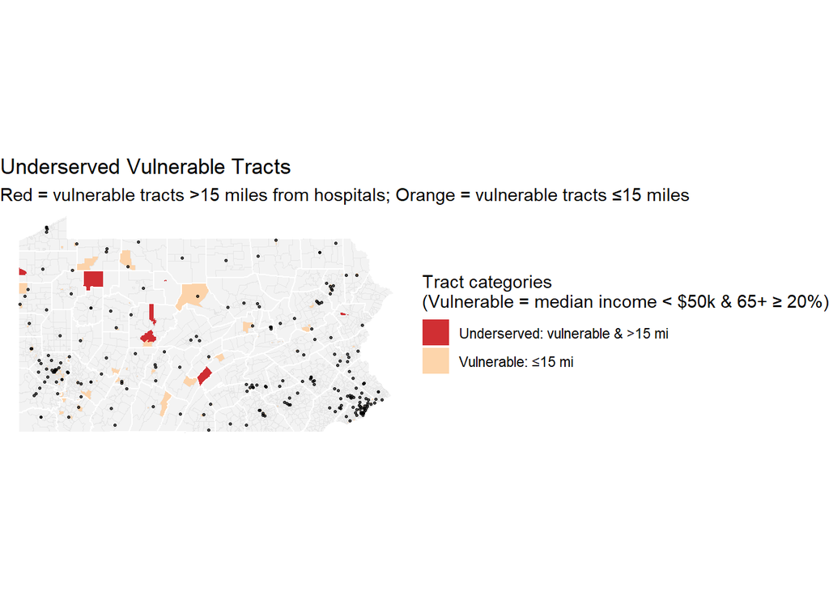

```r
# Create detailed tract-level map
base_tracts <- census_tracts %>% st_transform(st_crs(pa_counties))
vuln_map    <- vulnerable_tracts %>%
  st_transform(st_crs(pa_counties)) %>%
  mutate(status = ifelse(underserved, "Underserved (>15 mi)", "Vulnerable (≤15 mi)"))
hosp_map    <- hospitals %>% st_transform(st_crs(pa_counties))

#Plot
ggplot() +
  geom_sf(data = base_tracts, fill = "#f3f3f3", color = "grey90", linewidth = 0.15, show.legend = FALSE) +
  geom_sf(data = vuln_map, aes(fill = status), color = NA, alpha = 0.9) +
  geom_sf(data = pa_counties, fill = NA, color = "white", linewidth = 0.4) +
  geom_sf(data = hosp_map, color = "black", size = 0.6, alpha = 0.7, show.legend = FALSE) +
  scale_fill_manual(
    values = c("Vulnerable (≤15 mi)" = "#fdd0a2",
               "Underserved (>15 mi)" = "#cb181d"),
    name = "Tract categories\n(Vulnerable = median income < $50k & 65+ ≥ 20%)",
    labels = c(
      "Underserved (>15 mi)" = "Underserved: vulnerable & >15 mi",
      "Vulnerable (≤15 mi)" = "Vulnerable: ≤15 mi"
    )
  ) +
  guides(fill = guide_legend(title.position = "top")) +
  labs(
    title = "Underserved Vulnerable Tracts",
    subtitle = "Red = vulnerable tracts >15 miles from hospitals; Orange = vulnerable tracts ≤15 miles",
  ) +
  theme_void() +
  theme(legend.position = "right")
```

### Chart: Distribution Analysis

Create a visualization showing the distribution of distances to hospitals for vulnerable populations.

**Your Task:**

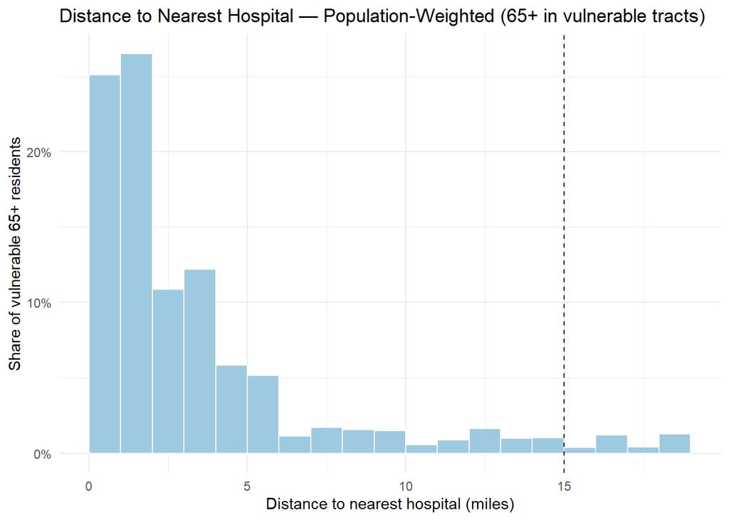

```r
# Create distribution visualization
vuln_dist <- vulnerable_tracts %>%
  sf::st_drop_geometry() %>%
  filter(is.finite(dist_mi)) %>%
  mutate(
    w65 = pmax(over65_total, 0)
  )

ggplot(
  vulnerable_tracts %>% sf::st_drop_geometry() %>%
    filter(is.finite(dist_mi)) %>%
    mutate(w65 = dplyr::coalesce(over65_total, 0)),
  aes(x = dist_mi)
) +
  geom_histogram(
    binwidth = 1, boundary = 0, closed = "left",
    aes(weight = w65, y = ..count.. / sum(..count..)),
    color = "white", fill = "#9ecae1"
  ) +
  geom_vline(xintercept = 15, linetype = "dashed") +
  scale_y_continuous(labels = scales::percent) +
  labs(
    title = "Distance to Nearest Hospital — Population-Weighted (65+ in vulnerable tracts)",
    x = "Distance to nearest hospital (miles)",
    y = "Share of vulnerable 65+ residents"
  ) +
  theme_minimal()
```

**Interpretation** - Most vulnerable tracts are only a few miles from a hospital. Only a small amount exceed the 15-Mile threshold, suggesting access problems are in rural areas.

#### Public Safety & Justice

**Crime & Community Resources** - **Data:** Crime Incidents, Recreation Centers, Libraries, Street Lights - **Question:** “Are high-crime areas underserved by community resources?” - **Operations:** Aggregate crime counts to census tracts or neighborhoods, count community resources per area, spatial correlation analysis - **Policy relevance:** Community investment, violence prevention strategies —

### Data Sources

**OpenDataPhilly:** https://opendataphilly.org/datasets/ - Most datasets available as GeoJSON, Shapefile, or CSV with coordinates - Always check the Metadata for a data dictionary of the fields.

**Additional Sources:** - **Pennsylvania Open Data:** https://data.pa.gov/ - **Census Bureau (via tidycensus):** Demographics, economic indicators, commute patterns - **TIGER/Line (via tigris):** Geographic boundaries

### Your Analysis

**Your Task:**

1. **Find and load additional data**

```r
# Crime Data
crime <- st_read("Data/incidents_part1_part2/incidents_part1_part2.shp", quiet = TRUE) %>%
  st_transform(3365)

libraries <- st_read("Data/Library/geo_export_57b98a32-c68d-462f-b3e9-187c05ad2dcd.shp", quiet = TRUE) %>%
  st_transform(3365)

rec_centers <- st_read("Data/PPR_Program_Sites/PPR_Program_Sites.shp", quiet = TRUE) %>%
  st_transform(3365)

# Philly boundary
pa_counties <- counties("PA", cb = TRUE, year = 2022) %>% st_transform(3365)
philly <- pa_counties %>% filter(NAME == "Philadelphia")

# Clip to philly boundary
crime       <- st_filter(crime,       philly, .predicate = st_intersects)
libraries   <- st_filter(libraries,   philly, .predicate = st_intersects)
rec_centers <- st_filter(rec_centers, philly, .predicate = st_intersects)

crime_homicide_all <- crime %>%
  dplyr::filter(trimws(text_gener) == "Homicide - Criminal")
```

3. **Conduct spatial analysis**

Use at least TWO spatial operations to answer your research question.

**Required operations (choose 2+):** - Buffers - Spatial joins - Spatial filtering with predicates - Distance calculations - Intersections or unions - Point-in-polygon aggregation

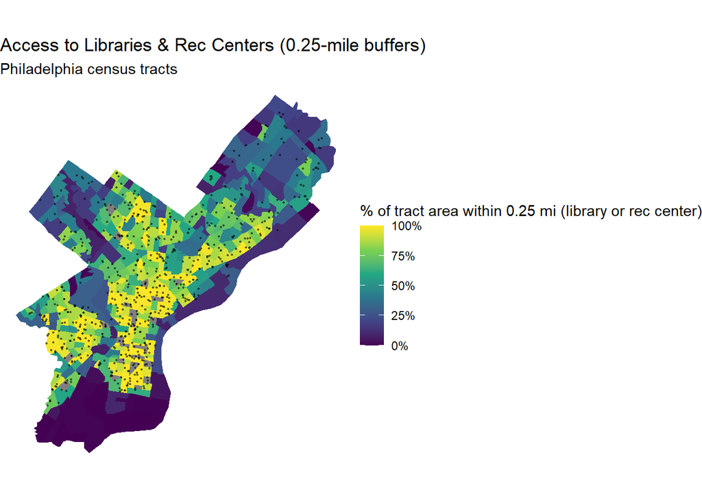

```r
# Resource buffers (0.25 mile = 1,320 ft)
buffer_ft <- 1320

resources <- bind_rows(
  libraries   %>% transmute(type = "Library",    geometry = st_geometry(.)),
  rec_centers %>% transmute(type = "Rec Center", geometry = st_geometry(.))
)

resources_buf_union <- resources %>%
  st_buffer(dist = buffer_ft) %>%
  st_union() %>%
  st_make_valid()

# Load tracts and population, compute tract area
phl_tracts <- tracts("PA", county = "Philadelphia", cb = TRUE, year = 2022) %>%
  st_transform(3365) %>%
  mutate(area_ft2 = as.numeric(st_area(geometry))) %>%
  select(GEOID, NAME, area_ft2, geometry)

pop <- get_acs(
  geography = "tract",
  variables = c(total_pop = "B01003_001"),
  state = "PA", county = "Philadelphia",
  year = 2022, output = "wide"
) %>% select(GEOID, total_pop = total_popE)

phl_tracts <- phl_tracts %>% left_join(pop, by = "GEOID")

# % of tract area within 0.25 miles of any resource
access_area_any <- phl_tracts %>%
  st_intersection(resources_buf_union) %>%
  mutate(covered_area_ft2_any = as.numeric(st_area(geometry))) %>%
  st_drop_geometry() %>%
  group_by(GEOID) %>%
  summarise(covered_area_ft2_any = sum(covered_area_ft2_any, na.rm = TRUE), .groups = "drop")

tract_access_any <- phl_tracts %>%
  left_join(access_area_any, by = "GEOID") %>%
  mutate(
    covered_area_ft2_any = coalesce(covered_area_ft2_any, 0),
    pct_area_any         = 100 * covered_area_ft2_any / area_ft2,
    people_within_025mi  = round(total_pop * (pct_area_any / 100), 0)
  ) %>%
  select(GEOID, NAME, total_pop, pct_area_any, people_within_025mi, geometry)

# Homicides Only
crime_homicide_all <- crime %>%
  dplyr::filter(trimws(text_gener) == "Homicide - Criminal")

# Per-tract homicide counts & rate per 100k (using ACS 2022 pop)
crime_by_tract <- crime_homicide_all %>%
  st_join(phl_tracts %>% select(GEOID), left = FALSE) %>%
  st_drop_geometry() %>%
  count(GEOID, name = "homicide_cnt")

tract_access_crime <- tract_access_any %>%
  left_join(crime_by_tract, by = "GEOID") %>%
  mutate(
    homicide_cnt       = replace_na(homicide_cnt, 0),
    homicide_rate_100k = if_else(total_pop > 0, homicide_cnt / total_pop * 1e5, NA_real_)
  )

# Thresholds
access_thresh_pct    <- 50
homicide_thresh_100k <- 30

# Map 1: Access
ggplot() +
  geom_sf(data = tract_access_any, aes(fill = pct_area_any), color = NA) +
  geom_sf(data = resources, color = "black", size = 0.3, alpha = 0.5, show.legend = FALSE) +
  scale_fill_viridis_c(
    name   = "% of tract area within 0.25 mi (library or rec center)",
    limits = c(0, 100),
    labels = function(x) paste0(x, "%")
  ) +
  labs(
    title    = "Access to Libraries & Rec Centers (0.25-mile buffers)",
    subtitle = "Philadelphia census tracts",
  ) +
  theme_void()
```

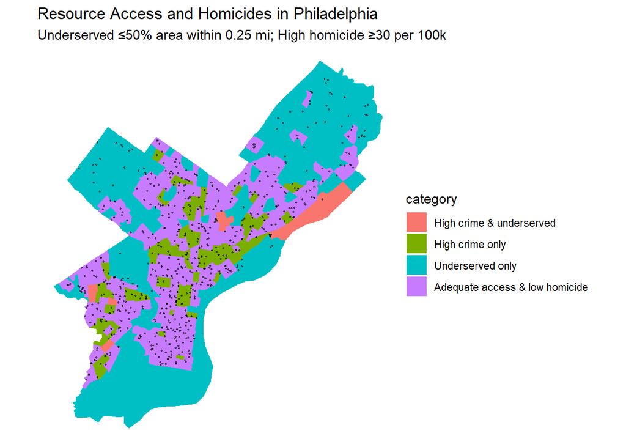

```r
# Map 2: Homicides and Access
tract_access_crime_map <- tract_access_crime %>%
  mutate(
    category = case_when(
      pct_area_any <= access_thresh_pct & homicide_rate_100k >= homicide_thresh_100k ~ "High crime & underserved",
      homicide_rate_100k >= homicide_thresh_100k                                     ~ "High crime only",
      pct_area_any <= access_thresh_pct                                              ~ "Underserved only",
      TRUE                                                                           ~ "Adequate access & low homicide"
    ),
    category = forcats::fct_relevel(
      category,
      "High crime & underserved","High crime only","Underserved only","Adequate access & low homicide"
    )
  )

ggplot() +
  geom_sf(data = tract_access_crime_map, aes(fill = category), color = NA) +
  geom_sf(data = resources, color = "black", size = 0.3, alpha = 0.5, show.legend = FALSE) +
  labs(
    title = "Resource Access and Homicides in Philadelphia",
    subtitle = paste0("Underserved ≤", access_thresh_pct, "% area within 0.25 mi; ",
                      "High homicide ≥", homicide_thresh_100k, " per 100k")
  ) +
  theme_void() +
  theme(legend.position = "right")
```

**Analysis requirements:** - Clear code comments explaining each step - Appropriate CRS transformations - Summary statistics or counts - At least one map showing your findings - Brief interpretation of results (3-5 sentences)

## Finally - A few comments about your incorporation of feedback!

Feedback from the first lab said that I needed to provide more explanations of what I’m doing. It also said to hide the setup code block, I tried to do that but I couldn’t figure out how to. It also said to print things in my console if it’s just for personal reference, so I did that in this assignment.

## Submission Requirements

**What to submit:**

1. **Rendered HTML document posted to your course portfolio** with all code, outputs, maps, and text
   - Use `embed-resources: true` in YAML so it’s a single file
   - All code should run without errors
   - All maps and charts should display correctly

**File naming:** `LastName_FirstName_Assignment2.html` and `LastName_FirstName_Assignment2.qmd`